# Projekt 1. PCA i MDS

## 1.3 Zad3

**Show and hide code**

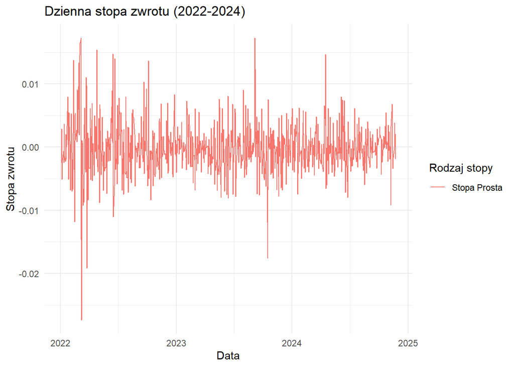

```r
# Zad3 --------------------------------------------------------------------

### Dane dzienne
# Wykres dziennych stóp zwrotu, stopa prosta
ggplot(europln_d_filtered, aes(x = Data)) +
  geom_line(aes(y = Stopa_Prosta, color = "Stopa Prosta")) +
  labs(title = "Dzienna stopa zwrotu (2022-2024)", y = "Stopa zwrotu", color = "Rodzaj stopy") +
  theme_minimal()
```

**Show and hide code**

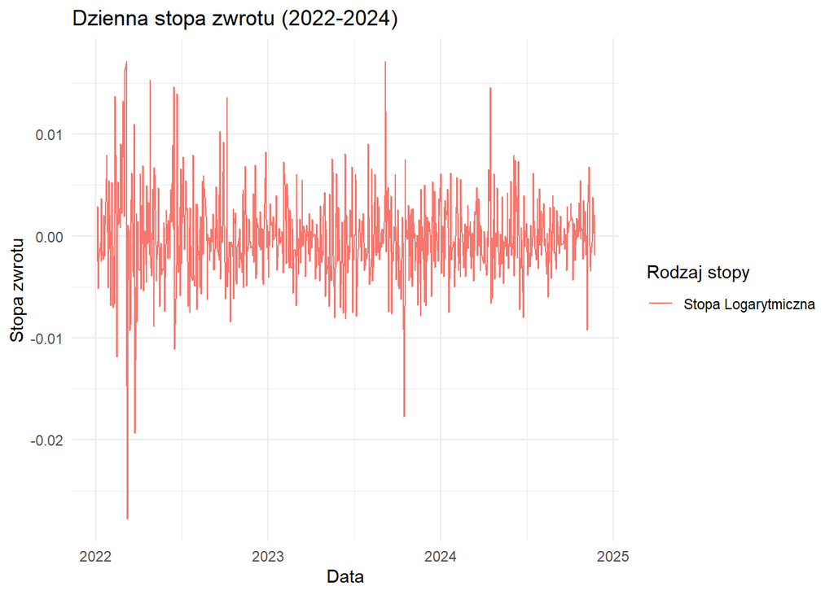

```r
# Wykres dzennych stóp zwrotu, stopa logarytmiczna
ggplot(europln_d_filtered, aes(x = Data)) +
  geom_line(aes(y = Stopa_Logarytmiczna, color = "Stopa Logarytmiczna")) +
  labs(title = "Dzienna stopa zwrotu (2022-2024)", y = "Stopa zwrotu", color = "Rodzaj stopy") +
  theme_minimal()
```

**Show and hide code**

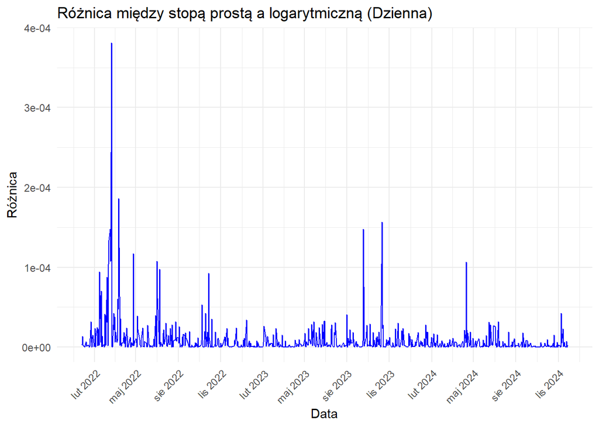

```r
# Wykres różnicy między stopą prostą i logarytmiczną - dzienne
ggplot(europln_d_filtered, aes(x = Data, y = Stopa_Prosta - Stopa_Logarytmiczna)) +
  geom_line(color = "blue") +
  scale_x_date(date_labels = "%b %Y", date_breaks = "3 months") +
  labs(title = "Różnica między stopą prostą a logarytmiczną (Dzienna)",
       y = "Różnica", x = "Data") +
  theme_minimal() +
  theme(axis.text.x = element_text(angle = 45, hjust = 1))
```

**Show and hide code**

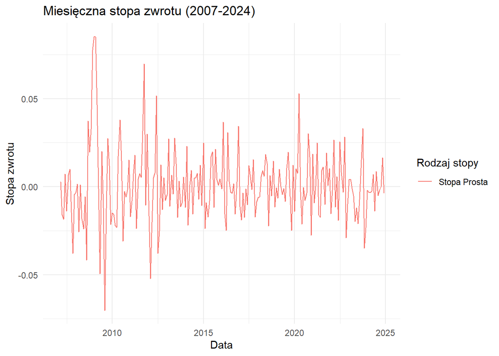

```r
### Dane miesięczne
# Wykres miesięcznych stóp zwrotu, stopa prosta
ggplot(europln_m_filtered, aes(x = Data)) +
  geom_line(aes(y = Stopa_Prosta, color = "Stopa Prosta")) +
  labs(title = "Miesięczna stopa zwrotu (2007-2024)", y = "Stopa zwrotu", color = "Rodzaj stopy") +
  theme_minimal()
```

**Show and hide code**

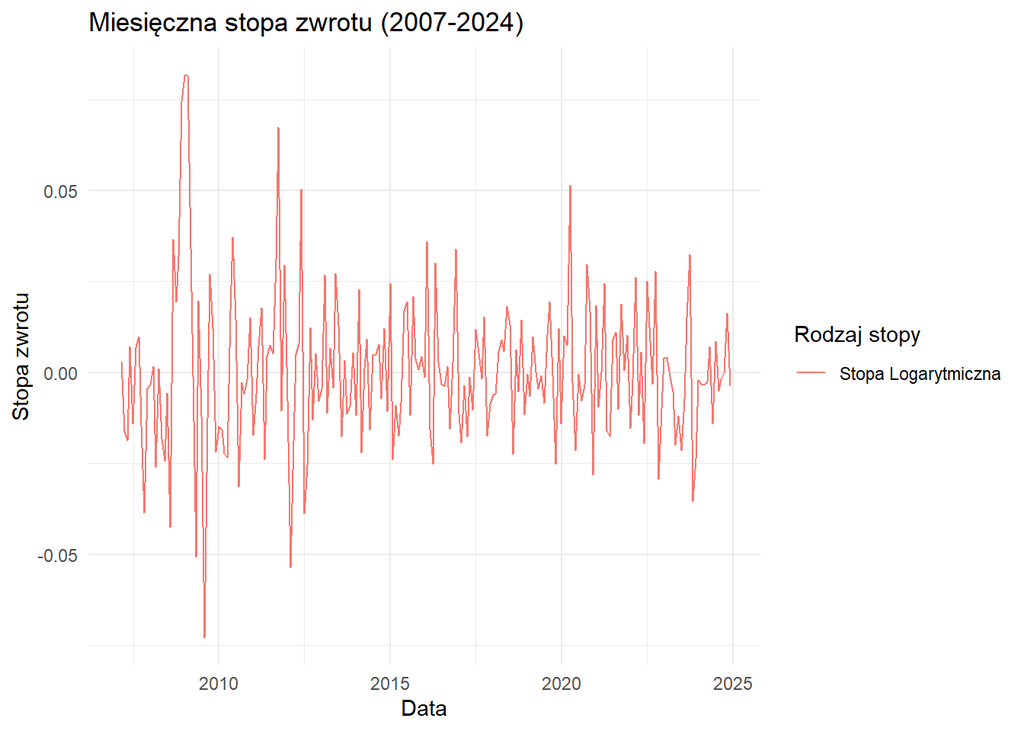

```r
# Wykres miesięcznych stóp zwrotu, stopa logarytmiczna
ggplot(europln_m_filtered, aes(x = Data)) +
  geom_line(aes(y = Stopa_Logarytmiczna, color = "Stopa Logarytmiczna")) +
  labs(title = "Miesięczna stopa zwrotu (2007-2024)", y = "Stopa zwrotu", color = "Rodzaj stopy") +
  theme_minimal()
```

**Show and hide code**

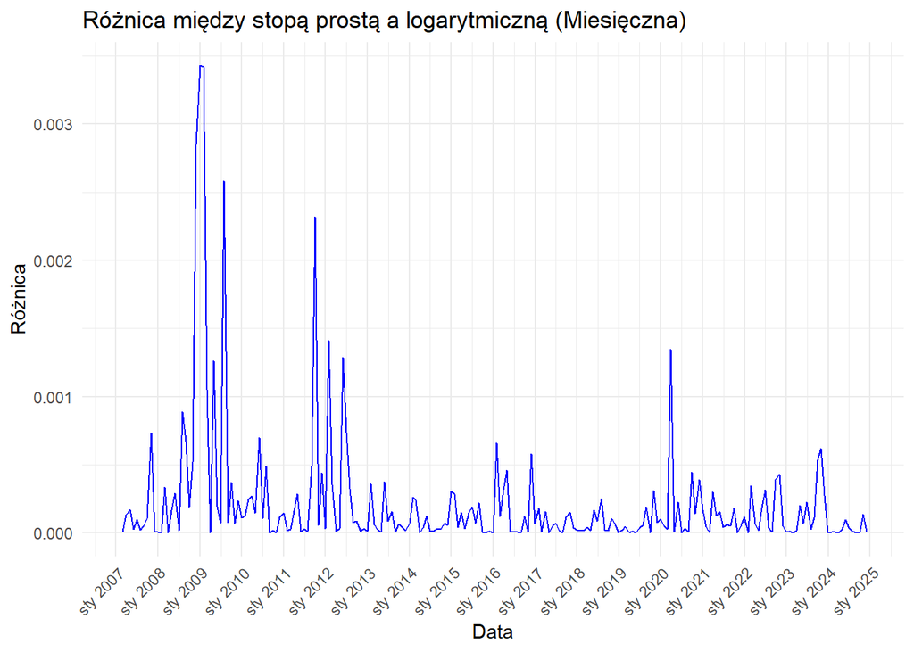

```r
# Wykres różnicy między stopą prostą i logarytmiczną - miesięczne
ggplot(europln_m_filtered, aes(x = Data, y = Stopa_Prosta - Stopa_Logarytmiczna)) +
  geom_line(color = "blue") +
  scale_x_date(date_labels = "%b %Y", date_breaks = "1 year") +
  labs(title = "Różnica między stopą prostą a logarytmiczną (Miesięczna)",
       y = "Różnica", x = "Data") +
  theme_minimal() +
  theme(axis.text.x = element_text(angle = 45, hjust = 1))
```

W okresach duzych wahań n arynku różnice są bardzo widoczne można zauważyć, iż stopa logarytmiczna jest lepszym przybliżeniem dla większych zmian Dla miesięcznych stóp zwrotu różnice są bardziej zauważalne

## 1.4 zad4

**Show and hide code**

```r
# Zad4 --------------------------------------------------------------------

# p-value < 0.05 to odrzucamy H0 o normalności rozkładów

d_daily <- na.omit(europln_d_filtered$Stopa_Logarytmiczna)
d_weekly <- na.omit(europln_w_filtered$Stopa_Logarytmiczna)
d_monthly <- na.omit(europln_m_filtered$Stopa_Logarytmiczna)

test_normalnosci <- function(data, nazwa) {
  cat("\n", nazwa, "\n")
  cat("Shapiro-Wilk Test: p-value =", shapiro.test(data)$p.value, "\n")
  cat("Anderson-Darling Test: p-value =", ad.test(data)$p.value, "\n")
  cat("Kolmogorov-Smirnov Test: p-value =", ks.test(data, "pnorm", mean(data), sd(data))$p.value, "\n")
}
```

dzienna

**Show and hide code**

```r
#dla danych dziennych
test_normalnosci(d_daily, "Dzienna logarytmiczna stopa zwrotu")
```

```
 Dzienna logarytmiczna stopa zwrotu
Shapiro-Wilk Test: p-value = 3.314575e-16
Anderson-Darling Test: p-value = 7.689669e-18
Kolmogorov-Smirnov Test: p-value = 0.0003502986
```

Wszystkie testy wskazują iż należy odzrucić hipoteze H0, a więc rozkład nie jest normalny

tygodniowa

**Show and hide code**

```r
#dla danych tygodniowych
test_normalnosci(d_weekly, "Tygodniowa logarytmiczna stopa zwrotu")
```

```
 Tygodniowa logarytmiczna stopa zwrotu
Shapiro-Wilk Test: p-value = 1.073651e-09
Anderson-Darling Test: p-value = 6.65258e-07
Kolmogorov-Smirnov Test: p-value = 0.02041415
```

Wszystkie testy wskazują iż należy odzrucić hipoteze H0, a więc rozkład nie jest normalny

miesięczna

**Show and hide code**

```r
#dla danych miesięcznych
test_normalnosci(d_monthly, "Miesięczna logarytmiczna stopa zwrotu")
```

```
 Miesięczna logarytmiczna stopa zwrotu
Shapiro-Wilk Test: p-value = 1.705908e-06
Anderson-Darling Test: p-value = 2.758483e-05
Kolmogorov-Smirnov Test: p-value = 0.1812473
```

test Kolomogorov-Smirnov wskazuje na rozk.normalny pozostałe testy Odrzycają hipoteze zerową przeważają testy odrzucające normalność, więc możemy uznać, że miesięczne stopy zwrotu również nie mają rozkładu normalnego, choć są bliższe normalności niż stopy dzienne czy tygodniowe.

## 1.5 Zad1.1

**Show and hide code**

```r
# Zad1.1** ----------------------------------------------------------------

# obliczenia teoretyczne częstości dla każdego podziału
# przy założeniu roz.normalnego oraz porówanie ich z empirycznymi wartościami z danych stóp zwrotu


# średnia i odch.standardowe dla dziennych logarytmicznych stóp zwrotu

mean_d <- mean(europln_d_filtered$Stopa_Logarytmiczna, na.rm = TRUE)
sd_d <- sd(europln_d_filtered$Stopa_Logarytmiczna, na.rm = TRUE)

# w pierwszej kolejności dziele dane na kategorie względem odchyleń std.
europln_d_filtered <- europln_d_filtered |>
  mutate(
    SD_category = case_when(
      Stopa_Logarytmiczna >= mean_d - sd_d & Stopa_Logarytmiczna <= mean_d + sd_d ~ "<1 SD",
      abs(Stopa_Logarytmiczna - mean_d) > sd_d & abs(Stopa_Logarytmiczna - mean_d) <= 2 * sd_d ~ "1-2 SD",
      abs(Stopa_Logarytmiczna - mean_d) > 2 * sd_d & abs(Stopa_Logarytmiczna - mean_d) <= 3 * sd_d ~ "2-3 SD",
      abs(Stopa_Logarytmiczna - mean_d) > 3 * sd_d & abs(Stopa_Logarytmiczna - mean_d) <= 4 * sd_d ~ "3-4 SD",
      abs(Stopa_Logarytmiczna - mean_d) > 4 * sd_d & abs(Stopa_Logarytmiczna - mean_d) <= 5 * sd_d ~ "4-5 SD",
      abs(Stopa_Logarytmiczna - mean_d) > 5 * sd_d ~ ">5 SD",
      TRUE ~ NA_character_
    )
  )

# Liczba obserwacji w każdej kategorii
empir_counts <- table(europln_d_filtered$SD_category, useNA = "no")

# Symulacja teoretycznego rozkładu normalnego
set.seed(123)
n <- nrow(europln_d_filtered)

simulated_returns <- rnorm(n, mean = mean_d, sd = sd_d)

simulated_categories <- cut(abs(simulated_returns - mean_d),
                            breaks = c(0, sd_d, 2 * sd_d, 3 * sd_d, 4 * sd_d, 5 * sd_d, Inf),
                            labels = c("<1 SD", "1-2 SD", "2-3 SD", "3-4 SD", "4-5 SD", ">5 SD"),
                            include.lowest = TRUE)

theoretical_counts <- table(simulated_categories)


# Porównanie teoretyczne i empiryczne -------------------------------------

# Tworzenie ramki danych do porównania
comparison <- data.frame(
  Interval = c("<1 SD", "1-2 SD", "2-3 SD", "3-4 SD", "4-5 SD", ">5 SD"),
  Empirical_Count = as.numeric(empir_counts),
  Theoretical_Count = as.numeric(theoretical_counts)
)

# Wydrukowanie porównania
print(comparison)
```

[output not shown]

**Show and hide code**

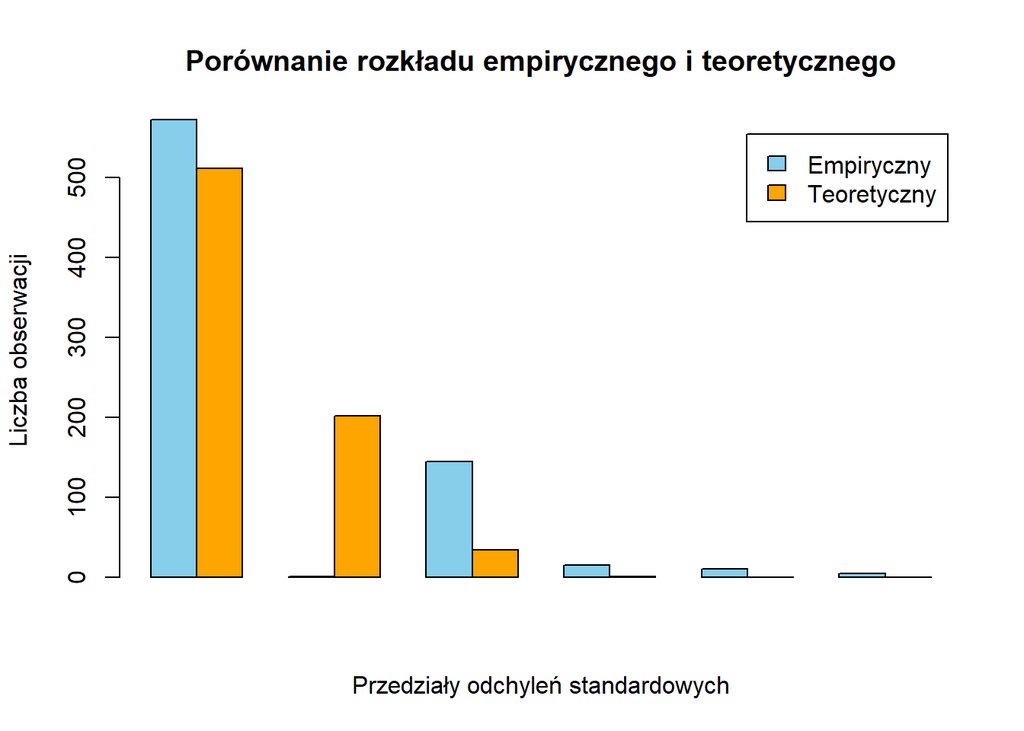

```r
# Wykres porównawczy
barplot(t(as.matrix(comparison[, -1])), beside = TRUE,
        legend.text = c("Empiryczny", "Teoretyczny"),
        col = c("skyblue", "orange"),
        main = "Porównanie rozkładu empirycznego i teoretycznego",
        xlab = "Przedziały odchyleń standardowych", ylab = "Liczba obserwacji")
```

Analiza symetrii: liczba wzrostów i spadków w każdej kategorii

**Show and hide code**

```r
europln_d_filtered <- europln_d_filtered |>
  mutate(Direction = ifelse(Stopa_Logarytmiczna >= mean_d, "Wzrost", "Spadek"))

symmetry_counts <- table(europln_d_filtered$SD_category, europln_d_filtered$Direction)
print(symmetry_counts)
```

```
         Spadek Wzrost
  <1 SD     310    263
  >5 SD       1      0
  1-2 SD     72     73
  2-3 SD      6      9
  3-4 SD      1      9
  4-5 SD      2      2
```

Czy duże zmiany (wzrosty/spadki) są symetryczne, (tj. jest ich mniej więcej tyle samo)? w niektórych przedziałach wartosci sapdków i wzrostów są podobne, jednak zmiany nie są symetryczne przykładowo: W przedziale <1 SD liczba spadków (310) i wzrostów (263) W przedziale 3-4 SD wzrostów jest wyraźnie więcej (9 wzrostów vs 1 spadek). Dla dużych zmian wzrosty występują częściej niż spadki

# 2 Część 2

**Show and hide code**

```r
library(dplyr)
library(ggplot2)
library(tidyr)
library(lmtest)
```

**Show and hide code**

```r
# dane dzienne walutowe
europln_d <- read.csv("C:/Users/mikol/OneDrive/Desktop/Pomiary_Ryzyka/waluty/europln/eurpln_dziennie.csv")

str(europln_d)
```

```
'data.frame':   4604 obs. of  5 variables:
 $ Data      : chr  "2007-01-02" "2007-01-03" "2007-01-04" "2007-01-05" ...
 $ Otwarcie  : num  3.82 3.83 3.84 3.89 3.88 ...
 $ Najwyzszy : num  3.83 3.83 3.89 3.91 3.89 ...
 $ Najnizszy : num  3.82 3.82 3.83 3.86 3.86 ...
 $ Zamkniecie: num  3.82 3.83 3.89 3.88 3.86 ...
```

**Show and hide code**

```r
europln_d$Data <- as.Date(europln_d$Data, format = "%Y-%m-%d")

# dane od 2012 do 2023
europln_d_filtered <- subset(europln_d, Data >= as.Date("2012-01-01") & Data <= as.Date("2023-12-31"))
```

## 2.1 Zadanie 1

**Show and hide code**

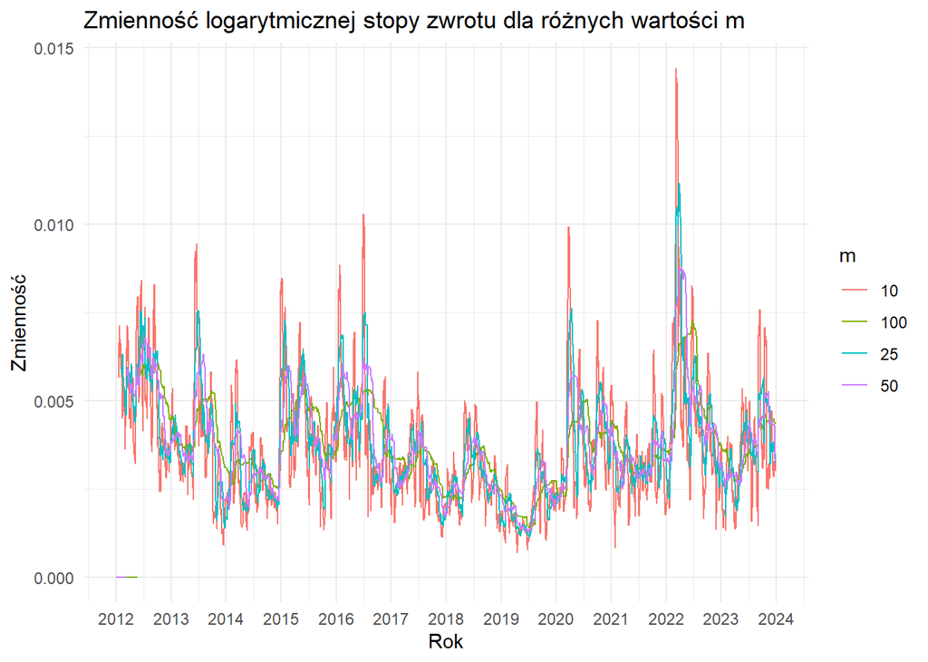

```r
# Zad1 --------------------------------------------------------------------

##POLECENIE
#Dla wybranego przez Ciebie zestawu danych, na podstawie pierwszego, podanego na wykładzie wzoru,
#wyznaczyć zmienność stóp zwrotu (przyjąć m = 10, 25, 50 i 100). Wyniki przedstawić na wykresie.
#Jak wykres zależy od wyboru wartości m?

# stopy logarytmiczna i stopa prosta
europln_d_filtered <- europln_d_filtered |>
  mutate(
    Stopa_Prosta = (Zamkniecie - dplyr::lag(Zamkniecie)) / dplyr::lag(Zamkniecie),
    Stopa_Logarytmiczna = log(Zamkniecie / dplyr::lag(Zamkniecie))
  )

# wzór1
oblicz_zmiennosc <- function(stopy, m) {
  n <- length(stopy)
  zmiennosc <- numeric(n)
  for (i in seq(m, n)) {
    zmiennosc[i] <- sqrt(sum(stopy[(i - m + 1):i]^2) / m)
  }
  return(zmiennosc)
}


m_values <- c(10, 25, 50, 100)

# do 1
for (m in m_values) {
  europln_d_filtered <- europln_d_filtered |>
    mutate(!!paste0("Zmiennosc_Logarytmiczna_m", m) := oblicz_zmiennosc(Stopa_Logarytmiczna, m))
}


zmiennosc_dlugie <- europln_d_filtered |>
  select(Data, starts_with("Zmiennosc_Logarytmiczna_")) |>
  pivot_longer(
    cols = starts_with("Zmiennosc_Logarytmiczna_"),
    names_to = "Okres",
    names_prefix = "Zmiennosc_Logarytmiczna_m",
    values_to = "Zmiennosc"
  )

ggplot(zmiennosc_dlugie, aes(x = Data, y = Zmiennosc, color = Okres)) +
  geom_line() +
  scale_x_date(date_breaks = "1 year", date_labels = "%Y") +
  labs(
    title = "Zmienność logarytmicznej stopy zwrotu dla różnych wartości m",
    y = "Zmienność", x = "Rok", color = "m"
  ) +
  theme_minimal()
```

jak widać im mniejsz m, krótkoterminowa zmiennośc jest bardziej szpiczasta widać więcej wznosów i górowań, co oznacza że wsk. jest bardziej podatny na w rynkowe wykres bardziej reaguje na pojedyncze duże zmiany cen Natomiast czym większe m, zmienność staje się bardziej wygładzona, mniej gwałtownych skoków

## 2.2 Zad2

**Show and hide code**

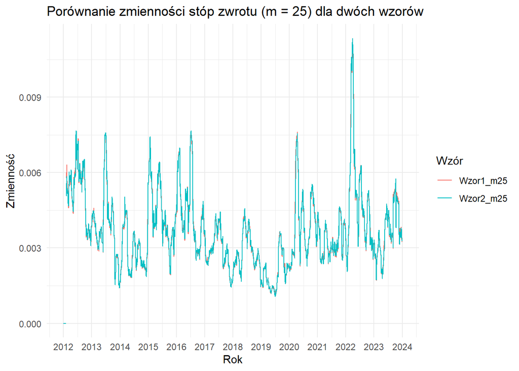

```r
#wzór 2
oblicz_zmiennosc2 <- function(stopy, m) {
  n <- length(stopy)
  zmiennosc <- numeric(n)

  for (i in seq(m, n)) {
    ostatnie_m <- stopy[(i - m + 1):i]
    srednia_m <- mean(ostatnie_m)
    zmiennosc[i] <- sqrt(sum((ostatnie_m - srednia_m)^2) / (m - 1))
  }

  return(zmiennosc)
}

m2 <- 25

# Obliczenie zmienności dla obu wzorów
europln_d_filtered <- europln_d_filtered |>
  mutate(
    Zmiennosc_Wzor1_m25 = oblicz_zmiennosc(Stopa_Logarytmiczna, m2),
    Zmiennosc_Wzor2_m25 = oblicz_zmiennosc2(Stopa_Logarytmiczna, m2)
  )


zmiennosc_porownanie <- europln_d_filtered %>%
  select(Data, Zmiennosc_Wzor1_m25, Zmiennosc_Wzor2_m25) %>%
  pivot_longer(
    cols = starts_with("Zmiennosc"),
    names_to = "Wzor",
    names_prefix = "Zmiennosc_",
    values_to = "Zmiennosc"
  )

ggplot(zmiennosc_porownanie, aes(x = Data, y = Zmiennosc, color = Wzor)) +
  geom_line() +
  scale_x_date(date_breaks = "1 year", date_labels = "%Y") +
  labs(
    title = "Porównanie zmienności stóp zwrotu (m = 25) dla dwóch wzorów",
    x = "Rok",
    y = "Zmienność",
    color = "Wzór"
  ) +
  theme_minimal()
```

Podobieństwo między liniami jest bardzo duże kiedy nie występują duże skoki danych Różnice występują w momentach dużych skoków zmienności , wzór 1 jest bardziej podatny na skrajne wartości uproszczenie procedury liczenia zmienności, nie powodują dużych zakłóceń w wyznaczanej wartości zmienności.

## 2.3 Zad3

**Show and hide code**

```r
# Zad3 --------------------------------------------------------------------
europln_d_filtered <- europln_d_filtered %>%
  mutate(across(where(is.numeric), ~ ifelse(is.na(.), 0, .)))
sum(is.na(europln_d_filtered))
```

```
[1] 0
```

**Show and hide code**

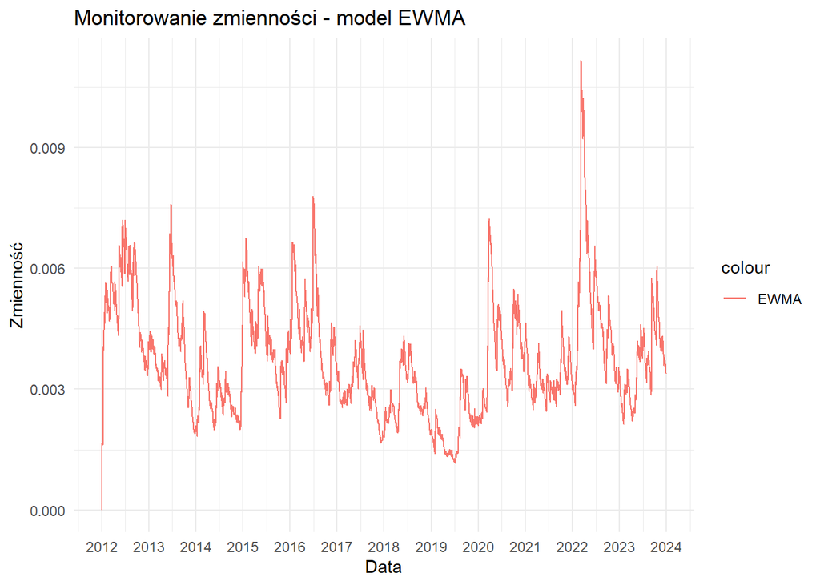

```r
####EWMA

oblicz_ewma <- function(stopy, lambda) {
  n <- length(stopy)
  ewma <- numeric(n)
  ewma[1] <- stopy[1]^2 # Pierwsza wartość inicjalizacyjna

  for (t in 2:n) {
    ewma[t] <- lambda * ewma[t-1] + (1 - lambda) * stopy[t-1]^2
  }
  return(sqrt(ewma)) # odchylenie standardowe
}

lambda <- 0.94
ewma_zmiennosc <- oblicz_ewma(europln_d_filtered$Stopa_Logarytmiczna, lambda)

europln_d_filtered$EWMA <- ewma_zmiennosc #dodanie do tabeli dannych

ggplot(europln_d_filtered, aes(x = Data)) +
  geom_line(aes(y = EWMA, color = "EWMA")) +
  scale_x_date(date_breaks = "1 year", date_labels = "%Y") +
  labs(title = "Monitorowanie zmienności - model EWMA", y = "Zmienność", x = "Data") +
  theme_minimal()
```

**Show and hide code**

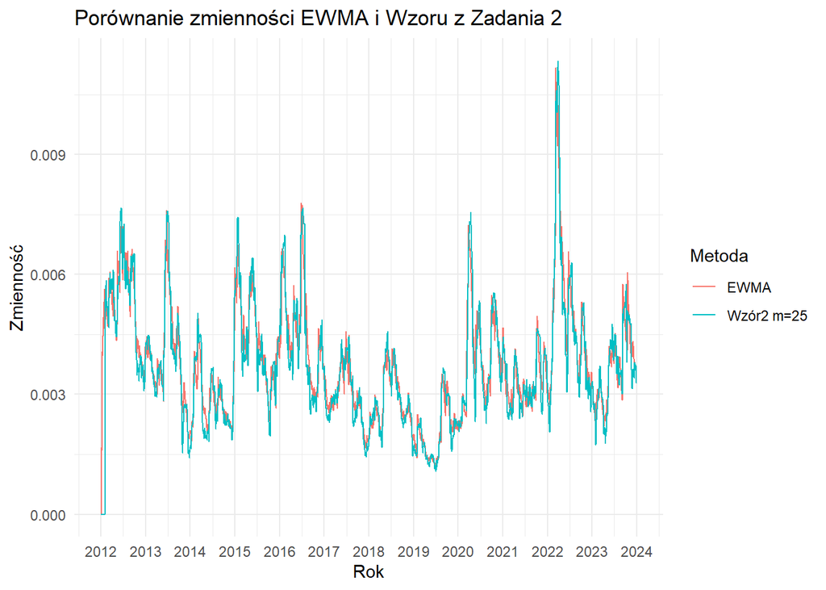

```r
# Porownanie EWMA i wzóru z zad 2
ggplot(europln_d_filtered, aes(x = Data)) +
  geom_line(aes(y = EWMA, color = "EWMA")) +
  geom_line(aes(y = Zmiennosc_Wzor2_m25, color = "Wzór2 m=25")) +
  scale_x_date(date_breaks = "1 year", date_labels = "%Y") +
  labs(title = "Porównanie zmienności EWMA i Wzoru z Zadania 2", x = "Rok", y = "Zmienność", color = "Metoda") +
  theme_minimal()
```

jak widać model EWMA jest niemal identyczny do tego z zad2, co prawda nie pokrywa się 1:1 z wykrezem z zad2

**Show and hide code**

```r
library(rugarch)

# Sprawdzenie długości danych (rugarch wymaga wektora danych)
stopy_log <- europln_d_filtered$Stopa_Logarytmiczna

# Specyfikacja modelu GARCH(1,1)
spec <- ugarchspec(
  variance.model = list(model = "sGARCH", garchOrder = c(1, 1)),
  mean.model = list(armaOrder = c(0, 0), include.mean = FALSE),
  distribution.model = "norm"
)

# Dopasowanie modelu do danych
fit <- ugarchfit(spec = spec, data = stopy_log)

# Wyciągnięcie wyników
print(fit)  # Podsumowanie wyników
```

```
*---------------------------------*
*          GARCH Model Fit        *
*---------------------------------*

Conditional Variance Dynamics
-----------------------------------
GARCH Model : sGARCH(1,1)
Mean Model  : ARFIMA(0,0,0)
Distribution    : norm

Optimal Parameters
------------------------------------
        Estimate  Std. Error  t value Pr(>|t|)
omega    0.00000    0.000001  0.18248  0.85521
alpha1   0.09020    0.045834  1.96799  0.04907
beta1    0.89985    0.041430 21.71946  0.00000

Robust Standard Errors:
        Estimate  Std. Error  t value Pr(>|t|)
omega    0.00000    0.000085 0.002627  0.99790
alpha1   0.09020    3.256704 0.027697  0.97790
beta1    0.89985    2.933418 0.306757  0.75903

LogLikelihood : 12989.28

Information Criteria
------------------------------------

Akaike       -8.3837
Bayes        -8.3778
Shibata      -8.3837
Hannan-Quinn -8.3816

Weighted Ljung-Box Test on Standardized Residuals
------------------------------------
                        statistic p-value
Lag[1]                     0.0137 0.90683
Lag[2*(p+q)+(p+q)-1][2]    2.0365 0.25678
Lag[4*(p+q)+(p+q)-1][5]    7.0839 0.04949
d.o.f=0
```

[output cut: 33 more lines]

```
Negative Sign Bias  0.2003 0.84127
Positive Sign Bias  1.4881 0.13683
Joint Effect        6.4754 0.09064   *


Adjusted Pearson Goodness-of-Fit Test:
------------------------------------
  group statistic p-value(g-1)
1    20     69.41    1.152e-07
2    30     85.04    2.069e-07
3    40    101.90    1.590e-07
4    50    114.43    3.757e-07


Elapsed time : 0.2457712
```

**Show and hide code**

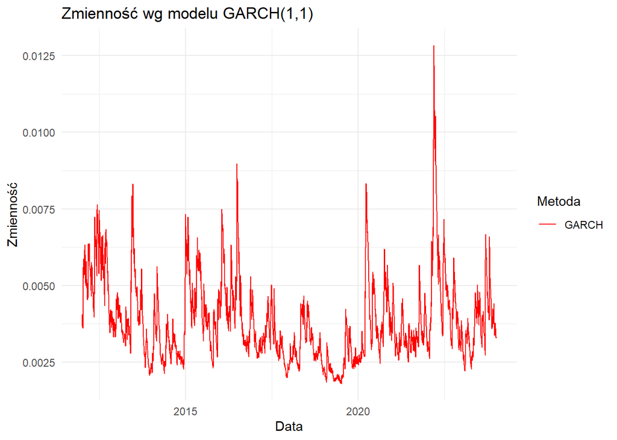

```r
# Warunkowa wariancja i zmienność
sigma_t <- sigma(fit)  # Zmienność (odchylenie standardowe)
sigma_t <- as.vector(sigma_t)  # Konwersja na wektor

# Dodanie wyników do tabeli
europln_d_filtered <- europln_d_filtered[seq_along(sigma_t), ]  # Dopasowanie długości
europln_d_filtered$GARCH_rugarch <- sigma_t

ggplot(europln_d_filtered, aes(x = Data)) +
  geom_line(aes(y = GARCH_rugarch, color = "GARCH")) +
  labs(title = "Zmienność wg modelu GARCH(1,1)", y = "Zmienność", x = "Data") +
  scale_color_manual(name = "Metoda", values = c("GARCH" = "red")) +
  theme_minimal()
```

## 2.4 Zadanie 4

**Show and hide code**

```r
# Zad4 --------------------------------------------------------------------

europln_d1 <- read.csv("C:/Users/mikol/OneDrive/Desktop/Pomiary_Ryzyka/waluty/europln/eurpln_dziennie.csv")
eurogbp_d1 <- read.csv("C:/Users/mikol/OneDrive/Desktop/Pomiary_Ryzyka/waluty/eurogbp/eurgbp_d.csv")
eurousd_d1 <- read.csv("C:/Users/mikol/OneDrive/Desktop/Pomiary_Ryzyka/waluty/eurousd/eurusd_d.csv")

europln_d1$Data <- as.Date(europln_d1$Data, format = "%Y-%m-%d")
eurogbp_d1$Data <- as.Date(eurogbp_d1$Data, format = "%Y-%m-%d")
eurousd_d1$Data <- as.Date(eurousd_d1$Data, format = "%Y-%m-%d")

europln_d_filtered1 <- subset(europln_d1, Data >= as.Date("2021-01-01") & Data <= as.Date("2021-10-31"))
eurogbp_d_filtered1 <- subset(eurogbp_d1, Data >= as.Date("2021-01-01") & Data <= as.Date("2021-10-31"))
eurousd_d_filtered1 <- subset(eurousd_d1, Data >= as.Date("2021-01-01") & Data <= as.Date("2021-10-31"))

# logarytmicznych stóp zwrotu dla EUR/PLN
europln_d_filtered1 <- europln_d_filtered1 |>
  mutate(Stopa_Logarytmiczna = log(Zamkniecie / dplyr::lag(Zamkniecie)))

# logarytmicznych stóp zwrotu dla EUR/GBP
eurogbp_d_filtered1 <- eurogbp_d_filtered1 |>
  mutate(Stopa_Logarytmiczna = log(Zamkniecie / dplyr::lag(Zamkniecie)))

# logarytmicznych stóp zwrotu dla EUR/USD
eurousd_d_filtered1 <- eurousd_d_filtered1 |>
  mutate(Stopa_Logarytmiczna = log(Zamkniecie / dplyr::lag(Zamkniecie)))

df <- data.frame(
  Data = europln_d_filtered1$Data,
  EUR_PLN = europln_d_filtered1$Stopa_Logarytmiczna,
  EUR_GBP = eurogbp_d_filtered1$Stopa_Logarytmiczna,
  EUR_USD = eurousd_d_filtered1$Stopa_Logarytmiczna
)

korelacja <- cor(df[,-1], use = "complete.obs")
korelacja
```

```
           EUR_PLN   EUR_GBP    EUR_USD
EUR_PLN  1.0000000 0.0142942 -0.2897633
EUR_GBP  0.0142942 1.0000000  0.2215549
EUR_USD -0.2897633 0.2215549  1.0000000
```

korelacja między kursami jest stosunkowo słaba. stopy zwrotu dla tych kursów nie wykazują silnych związków i mogą być bardziej niezależne od siebie.

## 2.5 Zad 5

Test DW

**Show and hide code**

```r
# Zad5 --------------------------------------------------------------------

# Test Durbina-Watsona (pierwszy rząd)
dwtest(Stopa_Logarytmiczna ~ 1, data = europln_d_filtered)
```

```
    Durbin-Watson test

data:  Stopa_Logarytmiczna ~ 1
DW = 1.9941, p-value = 0.4349
alternative hypothesis: true autocorrelation is greater than 0
```

nie odrzucamy H0 Brak autokorelacji rzędu pierwszego

Test Box.test

**Show and hide code**

```r
# Test Ljunga-Boxa dla wyższych rzędóww
Box.test(europln_d_filtered$Stopa_Logarytmiczna, lag =2 , type = "Ljung-Box")
```

```
    Box-Ljung test

data:  europln_d_filtered$Stopa_Logarytmiczna
X-squared = 15.635, df = 2, p-value = 0.0004026
```

**Show and hide code**

```r
Box.test(europln_d_filtered$Stopa_Logarytmiczna, lag =3 , type = "Ljung-Box")
```

```
    Box-Ljung test

data:  europln_d_filtered$Stopa_Logarytmiczna
X-squared = 15.862, df = 3, p-value = 0.00121
```

**Show and hide code**

```r
Box.test(europln_d_filtered$Stopa_Logarytmiczna, lag =4 , type = "Ljung-Box")
```

```
    Box-Ljung test

data:  europln_d_filtered$Stopa_Logarytmiczna
X-squared = 20.19, df = 4, p-value = 0.000458
```

**Show and hide code**

```r
Box.test(europln_d_filtered$Stopa_Logarytmiczna, lag =5 , type = "Ljung-Box")
```

```
    Box-Ljung test

data:  europln_d_filtered$Stopa_Logarytmiczna
X-squared = 27.53, df = 5, p-value = 4.496e-05
```

istotna autokorelacja Niska/negatywna korelacja zmniejsza ryzyko poprzez dywersyfikację. Wysoka pozytywna korelacja zwiększa ryzyko. Silna korelacja może zwiększać ryzyko skrajnych zmian wartości

**Show and hide code**

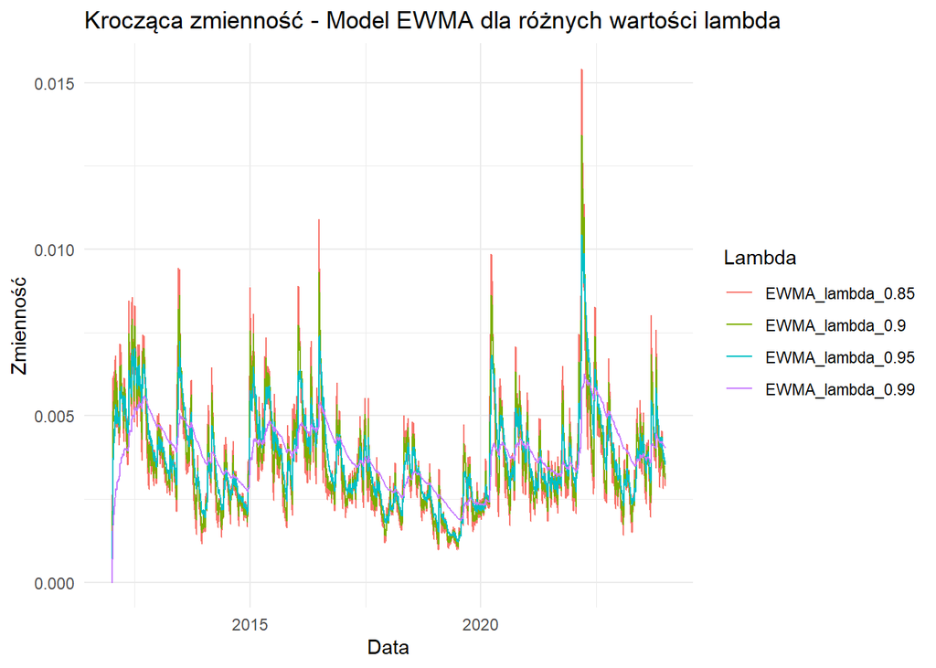

```r
# Zad6 --------------------------------------------------------------------

lambda_values <- c(0.85, 0.90, 0.95, 0.99)
for (lambda in lambda_values) {
  ewma_column <- oblicz_ewma(europln_d_filtered$Stopa_Logarytmiczna, lambda)
  column_name <- paste0("EWMA_lambda_", lambda)
  europln_d_filtered[[column_name]] <- ewma_column
}

ewma_porownanie <- europln_d_filtered %>%
  select(Data, starts_with("EWMA_lambda_")) %>%
  pivot_longer(
    cols = starts_with("EWMA_lambda_"),
    names_to = "Lambda",
    values_to = "Zmiennosc"
  )

ggplot(ewma_porownanie, aes(x = Data, y = Zmiennosc, color = Lambda)) +
  geom_line() +
  labs(
    title = "Krocząca zmienność - Model EWMA dla różnych wartości lambda",
    x = "Data",
    y = "Zmienność"
  ) +
  theme_minimal()
```

Mniejsze wartości lambda bardziej reagują na zmiany,są mniej stabilne czuły na krótko terminowe ruchy cenowe Większe wartości lambda mają bardziej wygładzoną zmienność, mniej dynamicznie reagują na skrajne ruchy cenowe. Redukuje wpływ nagłych skoków, bardziej stabilne

# 3 Zadanie 7

**Show and hide code**

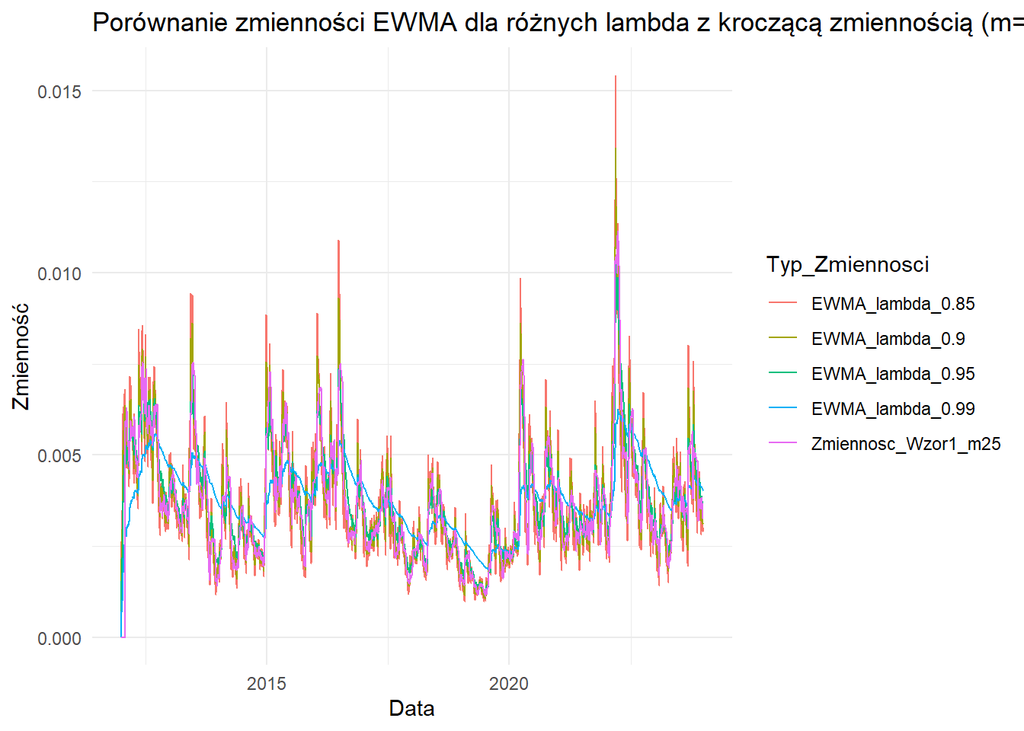

```r
# Zad 7 -------------------------------------------------------------------

m <- 25
europln_d_filtered$Zmiennosc_Wzor1_m25 <- oblicz_zmiennosc(europln_d_filtered$Stopa_Logarytmiczna, m)

zmiennosc_porownanie <- europln_d_filtered %>%
  select(Data, Zmiennosc_Wzor1_m25, starts_with("EWMA_lambda")) %>%
  pivot_longer(
    cols = -Data,
    names_to = "Typ_Zmiennosci",
    values_to = "Wartosc"
  )

ggplot(zmiennosc_porownanie, aes(x = Data, y = Wartosc, color = Typ_Zmiennosci)) +
  geom_line() +
  labs(title = "Porównanie zmienności EWMA dla różnych lambda z kroczącą zmiennością (m=25)",
       x = "Data", y = "Zmienność") +
  theme_minimal()
```

**Show and hide code**

```r
rmse <- function(actual, predicted) {
  sqrt(mean((actual - predicted)^2, na.rm = TRUE))
}

rmse_values <- sapply(lambda_values, function(lambda) {
  colname <- paste0("EWMA_lambda_", lambda)
  rmse(europln_d_filtered$Zmiennosc_Wzor1_m25, europln_d_filtered[[colname]])
})

names(rmse_values) <- lambda_values
rmse_values
```

```
        0.85          0.9         0.95         0.99
0.0008728163 0.0006436914 0.0005467333 0.0011123735
```

najlepiej sprawdzi sie lambda 0.95 oznacza to, że model EWMA z tym parametrem dobrze oddaje rzeczywistą zmienność kroczącą.